# BSG - Hardy-Weinberg Equilibrium

Ricard Gardella, Sofia B. Reichl

27th November 2018

# Exercise 1

**The file ABO-CHB.rda contains genotype information of individuals of a Chinese population of unrelated individuals. The genotype information concerns SNPs the ABO bloodgroup region, located on chromosome number 9. The file contains genotype information (Z, individuals in columns, SNPs in rows), the physical position of each SNP (pos) and the alleles for each SNP (alleles). Load this data into the R environment.**

Load the data:

```r
  load('/Users/ricardgardellagarcia/Documents/Master Data science/BSG/Part2/practiques/practica3/ABO-CHB.rda')
#load('C:/Master/3rd Semestre/BSG - Bioinformatics and Statistical Genetics/Statistical Genetics/Assignments/Assignment3/ABO-CHB.rda')
```

# Exercise 2

**How many individuals and how many SNPs are there in the database?**

```
## We have 45 individuals in the database.
```

```
## And we have 45 SNP's in the database.
```

**What percentage of the data is missing?**

```
## And we have 61 missing data in the total number of observations: 2025 on the dataset.
```

```
## So, that means we have a 3.012346 % of missing data (which is normal)
```

# Exercise 3

**Depict all SNPs simultaeneously in a ternary plot, and comment on your result. Do you believe Hardy-Weinberg equilibrium is tenable for the markers in this database?**

First of all we need to group all kind of genotypes we have in the dataset. We will use the typical structure where the individuals are in the rows and the different gentoypes are in the columns (grouped in AA, AB and BB).  
To do this we will use the *groupGenotype()* function from the genetics package. This requires a transformation of each column into a *genotype()* object.

```r
tmat <- t(Z)
# We've seen that in the dataset we have several combinations: AA, AT, AC, AG, AB...
#So we will transform it into AA, AB and BB (alleles)
map <- list('AA'=c('A/A'), 'TT'=c('T/T'), 'CC'=c('C/C'), 'GG'=c('G/G'), 'AB'='.else')
genome <- as.data.frame(matrix(NA,nrow=45,ncol=3))
names(genome) <- c('AA','AB','BB')
for(i in 1:ncol(tmat)){
  geno.table <- table(groupGenotype(x=genotype(tmat[,i], sep=''), map=map, factor=FALSE))
  if(length(geno.table)==3){
    genome[i,'AB'] <- geno.table['AB']
    geno.table <- geno.table[names(geno.table) != 'AB']
    genome[i,'AA'] <- geno.table[1]
    genome[i,'BB'] <- geno.table[2]
  }else if(length(geno.table)==2){
    genome[i,'AB'] <- geno.table['AB']
    geno.table <- geno.table[names(geno.table) != 'AB']
    genome[i,'AA'] <- geno.table[1]
  }else if(length(geno.table)==1){
    genome[i,'AB'] <- genocounts['AB']
    geno.table <- geno.table[names(geno.table) != 'AB']
    genome[i,'AA'] <- geno.table[1]
  }
}
# NA's will be 0
genome[is.na(genome)] <- 0
```

Now that we have the dataset we will to the HWTernaryPlot of it:

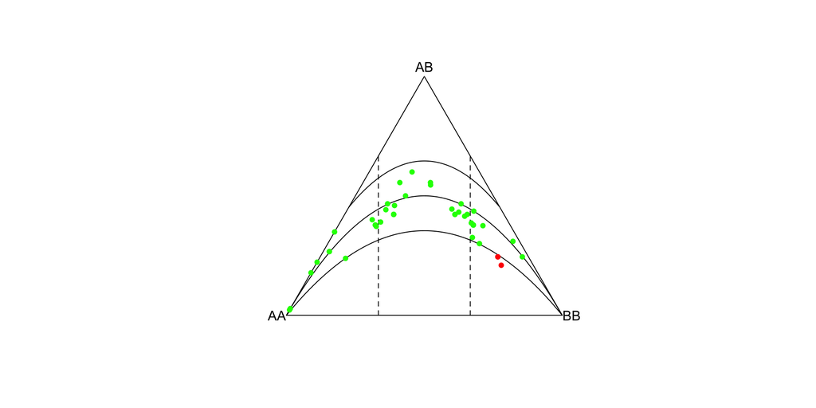

```r
HWTernaryPlot(genome)
```

# Exercise 4

**Using the function LD from the genetics package, compute the LD statistic D for the first two SNPs in the database. Is there significant association between these two SNPs?**

```r
SNP1 <- genotype(tmat[,1],sep="")
SNP2 <- genotype(tmat[,2],sep="")
(LD12 <- LD(SNP1,SNP2))
```

```
##
## Pairwise LD
## -----------
##                      D        D'       Corr
## Estimates: -0.01600862 0.9974604 -0.1449029
##
##               X^2  P-value  N
## LD Test: 1.889716 0.169234 45
```

```
## We've seen that in this case the D statistic for SNP1 and SNP2 is: -0.02
```

In order to know if there is a significant association between these we will take a look at the P-value of the Pairwise LD. It seems that there are no evidences to say that there is association between them, cause the pvalue takes a higher value than the $\alpha$ we decided to use ($\alpha=0.05$).

# Exercise 5

**Given your previous estimate of D, and using the formula from the lecture slides, compute the statistics $D'$; $\chi^2$;$R^2$ and $r$ by hand for the first pair of SNPs. Do your results coincide with those obtained by the LD function? Can you explain possible differences?**

First of all we will do some calcs in order to compute the statistics:

```r
D.fun <- LD12$D
t1 <- table(SNP1)
t2 <- table(SNP2)

# SNP1) A = G, a = A
pA = as.numeric(((t1[1]/2)+t1[2])/45)
pa = as.numeric(((t1[1]/2))/45)
#pA+pa==1

# SNP2) B = G, b = A
pB = as.numeric(((t2[2]/2)+t2[3])/45)
pb = as.numeric(((t2[2]/2)+t2[1])/45)
#pB+pb==1

pApB = pA*pB
pApb = pA*pb
papB = pa*pB
papb = pa*pb
#pApB+pApb+papB+papb==1
```

Now that we have the previous calcs we will do the calcs:

```r
Dmax = min(pApB, papb)
  `D'` = LD12$D/Dmax
R2 = D.fun^2 / (pApB*papb)
X2 = R2 * 2*nrow(tmat)
r = sqrt(R2)
```

```
## So, the final results are:
## - D' = -0.9974604
## - R2 = 0.02099684
## - X2 = 1.889716
## - r = 0.1449029
```

We can see that the results are quite similar than the ones obtained with the function. But, it is notorious that the D’ has different sign. Maybe the function applies the absolute value.

# Exercise 6

**Given your previous estimate of D, infer the haplotype frequencies. Which haplotype is the most common?**

To do that we will use the previous calcs we have done in the Exercise 5. These are the results:

```r
hPApB = pApB+D.fun
hPApb = pApb-D.fun
hPapB = papB-D.fun
hPapb = papb+D.fun
```

```
## In this case the final results are:
## - Frequency of GG = 0.7444852
## - Frequency of GA = 0.1444037
## - Frequency of AG = 0.1110704
## - Frequency of AA = 4.075852e-05
```

# Exercise 7

**Compute 4 LD statistics for all the marker pairs in this data base $D'$;$\chi^2$;$R^2$. Make a scatterplot matrix of these.**

```r
stats = NULL
c = matrix(data = 0, nrow=nrow(tmat), ncol=ncol(tmat))
for(i in 1:(ncol(tmat)-1)) {
  for(j in i:ncol(tmat)) {
    SNP1 <- genotype(tmat[,i],sep="")
    SNP2 <- genotype(tmat[,j],sep="")
    out <- LD(SNP1,SNP2)
    stats$D[c] <- out$D
    stats$`D'`[c] <- out$`D'`
    stats$`R^2`[c] <- out$`R^2`
    stats$`X^2`[c] <- out$`X^2`
    c = c+1
  }
}
```

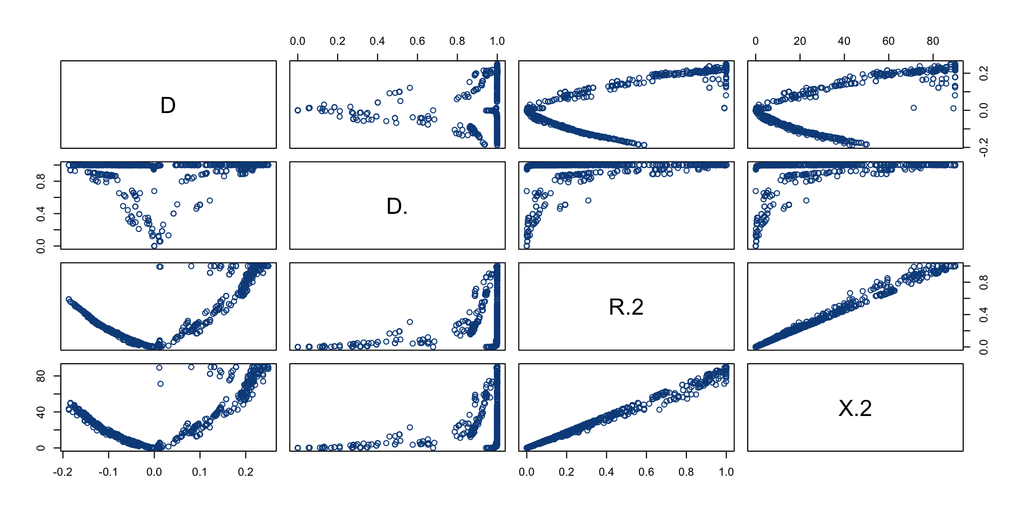

```r
pairs(stats,col="#0c4c8a")
```

# Exercise 8

**Compute a distance matrix with the distance in base pairs between all possible pairs of SNPs.**

**Make a plot of the $R^2$ statistics against the distance between the markers. Comment on your results.**

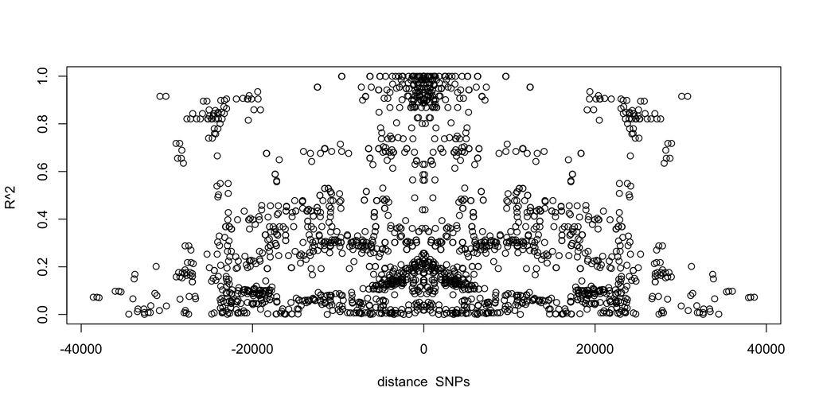

```r
distance_matrix <- matrix(data = NA, nrow = nrow(tmat), ncol= ncol(tmat))
r2_matrix <- matrix(data = 0, nrow = nrow(tmat), ncol= ncol(tmat))
for(i in 1:ncol(tmat)) {
  for(j in 1:ncol(tmat)) {
    distance_matrix[i,j] = pos[i]-pos[j]
    r2_matrix[i,j] <- LD(genotype(tmat[,i],sep=""),genotype(tmat[,j],sep=""))$`R^2`
  }
}
plot(distance_matrix, r2_matrix, ylab="R^2 ", xlab = "distance  SNPs")
```

# Exercise 9

**Make two LD heatmaps of the markers in this database, one using the R2 statistic and one using the $D'$ statistic, and use the positional information on the markers. Are the results consistent?**

We can observe that the results are not consistent

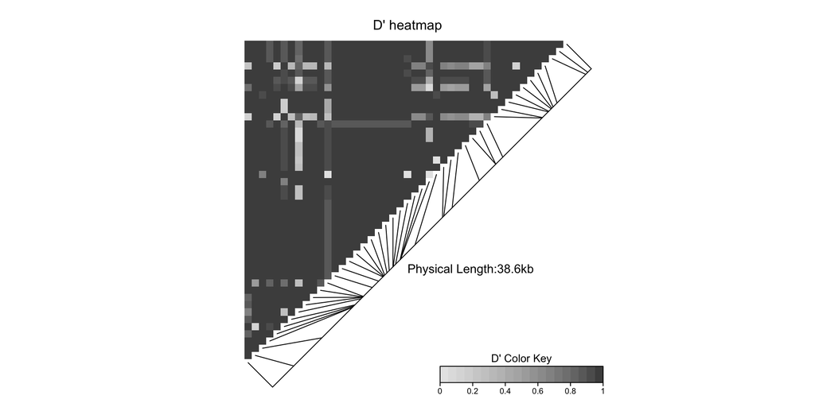

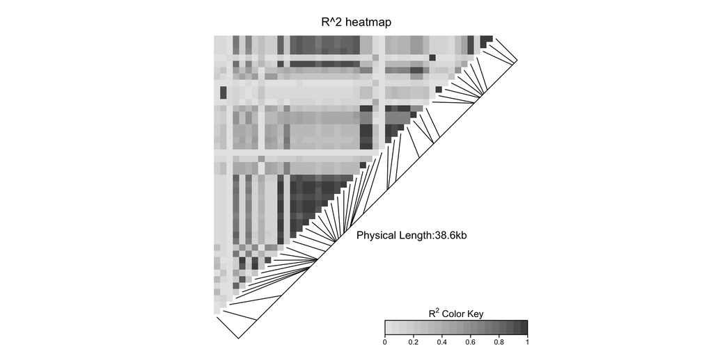

# Exercise 10

**Simulate 45 independent SNPs under the assumption of Hardy-Weinberg equilibrium, using R’s sample instruction:** *(sample(c(‘AA’,‘AB’,‘BB’),n,replace=TRUE,prob=c(p*p,2*p*q,q*q)))* **Simulate as many SNPs as you have in your database, and take care to match each SNP in your database with a simulated SNP that has the same sample size and allele frequency.**

**Make two LD heatmaps of the simulated SNPs, one using R2 and one using D0. Compare these to the LD heatmap of the ABO region. What do you observe? State your conclusions**

# Exercise 11

**Do you think there is strong or weak LD for the ABO region you just studied? Explain your opinion.**